# DSCI 100: Introduction to Data Science

## Tutorial 4: Effective Data Visualization Class Activity

### 2019-10-01

Create a new R Jupyter notebook.

Load the `tidyverse` and `repr` libraries and install and load the `plotly` library

```r
install.packages("plotly")
library(tidyverse)
library(plotly)
library(repr)
```

## Activity 1

We are interested in the distribution of the prices of diamonds which are **equal to or greater than 1 carat** and want to see it through a **histogram** in **$500** intervals.

First, take a look at the `diamonds` dataset and edit the dataset to fit our parameter of **equal to or greater than 1 carat**.

```r
## Solution
```

Now, make a **histogram** where we count the distribution of prices of diamonds which are **greater than or equal to 1 carat** in intervals of **$500**. Also, don't forget to size the plot appropriately and name the axes and legend.

Here is a hint taken from https://rstudio.com/resources/cheatsheets/

I recommend everyone take a look at this as they have cheat sheets for other libraries we use.

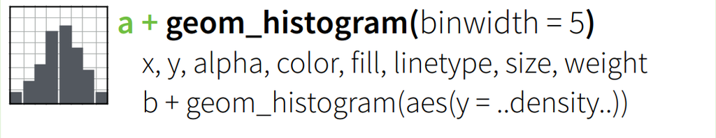

```r
## Solution
```

Now, what if we are interested in seeing the number of diamonds for each type of cut in each interval?

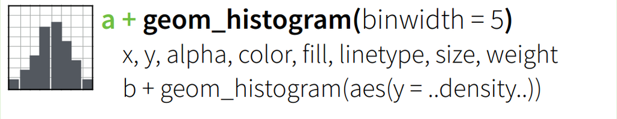

Hint: Look back at Worksheet_04 Questions 2.9.3 and 2.9.4 and see how they managed to add colour to distinguish the restaurant names

```r
## Solution
```

Now, we have separated the counts by colour, however, we still don't have a clear idea of how many diamonds per cut lie in our $500 intervals. There are many ways to tackle this problem. We will now use the `plotly` library we have just installed as one way to solve this.

```r
## Solution
```